# Tidyverse Exam v2.0

Solutions for [August 2020 Sample Exam](https://education.rstudio.com/blog/2020/08/more-example-exams/)

[Silvia Canelón](https://silvia.rbind.io)

```r
library(tidyverse)
```

## Basic operations

more-example-exams/#basic-operations

### Question 1

Read the file `person.csv` and store the result in a tibble called `person`.

```r
person <- read_csv("https://education.rstudio.com/blog/2020/08/more-example-exams/person.csv")
class(person)
```

```
## [1] "spec_tbl_df" "tbl_df"      "tbl"         "data.frame"
```

### Question 2

Create a tibble containing only family and personal names, in that order. You do not need to assign this tibble or any others to variables unless explicitly asked to do so. However, as noted in the introduction, you must use the pipe operator `%>%` and code that follows the tidyverse style guide.

```r
# View(person)

person %>%
  select(family_name, personal_name)
```

| family_name | personal_name |
| --- | --- |
| Dyer | William |
| Pabodie | Frank |
| Lake | Anderson |
| Roerich | Valentina |
| Danforth | Frank |

### Question 3

Create a new tibble containing only the rows in which family names come before the letter M. Your solution should work for tables with more rows than the example, i.e., you cannot rely on row numbers or select specific names.

```r
person %>%
  arrange(family_name) %>%
  filter(family_name < "M")
```

| person_id | personal_name | family_name |
| --- | --- | --- |
| danforth | Frank | Danforth |
| dyer | William | Dyer |
| lake | Anderson | Lake |

### Question 4

Display all the rows in person sorted by family name length with the longest name first.

```r
person %>%
  arrange(desc(str_length(family_name)))
```

| person_id | personal_name | family_name |
| --- | --- | --- |
| danforth | Frank | Danforth |
| pb | Frank | Pabodie |
| roe | Valentina | Roerich |
| dyer | William | Dyer |
| lake | Anderson | Lake |

## Cleaning and counting

[more-sample-exams/#cleaning-and-counting](https://education.rstudio.com/blog/2020/08/more-example-exams/#cleaning-and-counting)

### Question 1

Read the file measurements.csv to create a tibble called measurements. (The strings “rad”, “sal”, and “temp” in the quantity column stand for “radiation”, “salinity”, and “temperature” respectively.)

```r
measurements <- read_csv("https://education.rstudio.com/blog/2020/08/more-example-exams/measurements.csv")
```

### Question 2

Create a tibble containing only rows where none of the values are `NA` and save in a tibble called `cleaned.`

```r
cleaned <-
measurements %>%
  filter(!is.na(visitor), !is.na(quantity), !is.na(reading))

# other option: use na.omit(measurements)
```

### Question 3

Count the number of measurements of each type of quantity in `cleaned.` Your result should have one row for each quantity `"rad"`, `"sal"`, and `"temp"`.

```r
cleaned %>%
  group_by(quantity) %>%
  summarize(n())
```

| quantity | n() |
| --- | --- |
| rad | 8 |
| sal | 7 |
| temp | 3 |

```r
# other option: use count()
```

### Question 4

Display the minimum and maximum value of reading separately for each quantity in `cleaned`. Your result should have one row for each quantity `"rad"`, `"sal"`, and `"temp"`.

```r
cleaned %>%
  group_by(quantity) %>%
  summarize(min(reading), max(reading))
```

| quantity | min(reading) | max(reading) |
| --- | --- | --- |
| rad | 1.46 | 11.25 |
| sal | 0.05 | 41.60 |
| temp | -21.50 | -16.00 |

### Question 5

Create a tibble in which all salinity (`"sal"`) readings greater than 1 are divided by 100. (This is needed because some people wrote percentages as numbers from 0.0 to 1.0, but others wrote them as 0.0 to 100.0.)

```r
measurements %>%
  filter(quantity == "sal") %>%
  mutate(new_reading = ifelse(reading > 1, reading/100, reading))
```

| visit_id | visitor | quantity | reading | new_reading |
| --- | --- | --- | --- | --- |
| 619 | dyer | sal | 0.13 | 0.130 |
| 622 | dyer | sal | 0.09 | 0.090 |
| 734 | lake | sal | 0.05 | 0.050 |
| 735 | NA | sal | 0.06 | 0.060 |
| 751 | lake | sal | NA | NA |
| 752 | lake | sal | 0.09 | 0.090 |
| 752 | roe | sal | 41.60 | 0.416 |
| 837 | lake | sal | 0.21 | 0.210 |
| 837 | roe | sal | 22.50 | 0.225 |

```r
measurements %>%
  filter(quantity == "sal") %>%
  mutate(reading = reading/100)
```

| visit_id | visitor | quantity | reading |
| --- | --- | --- | --- |
| 619 | dyer | sal | 0.0013 |
| 622 | dyer | sal | 0.0009 |
| 734 | lake | sal | 0.0005 |
| 735 | NA | sal | 0.0006 |
| 751 | lake | sal | NA |
| 752 | lake | sal | 0.0009 |
| 752 | roe | sal | 0.4160 |
| 837 | lake | sal | 0.0021 |
| 837 | roe | sal | 0.2250 |

## Combining data

[more-sample-exams/#combining-data](https://education.rstudio.com/blog/2020/08/more-example-exams/#combining-data)

### Question 1

Read `visited.csv` and drop rows containing any `NA`s, assigning the result to a new tibble called `visited.`

```r
visited <-
  read_csv("https://education.rstudio.com/blog/2020/08/more-example-exams/visited.csv") %>%
  filter(!is.na(site_id), !is.na(visit_date))
```

### Question 2

Use an inner join to combine `visited` with `cleaned` using the `visit_id` column for matches.

```r
inner_join(visited, cleaned, by = "visit_id")
```

| visit_id | site_id | visit_date | visitor | quantity | reading |
| --- | --- | --- | --- | --- | --- |
| 619 | DR-1 | 1927-02-08 | dyer | rad | 9.82 |
| 619 | DR-1 | 1927-02-08 | dyer | sal | 0.13 |
| 622 | DR-1 | 1927-02-10 | dyer | rad | 7.80 |
| 622 | DR-1 | 1927-02-10 | dyer | sal | 0.09 |
| 734 | DR-3 | 1930-01-07 | pb | rad | 8.41 |
| 734 | DR-3 | 1930-01-07 | lake | sal | 0.05 |
| 734 | DR-3 | 1930-01-07 | pb | temp | -21.50 |
| 735 | DR-3 | 1930-01-12 | pb | rad | 7.22 |
| 751 | DR-3 | 1930-02-26 | pb | rad | 4.35 |
| 751 | DR-3 | 1930-02-26 | pb | temp | -18.50 |

[output cut: 4 more lines]

### Question 3

Find the highest radiation (`"rad"`) reading at each site. (Sites are identified by values in the `site_id` column.)

```r
inner_join(visited, cleaned, by = "visit_id") %>%
  group_by(site_id) %>%
  summarize(max(reading))
```

| site_id | max(reading) |
| --- | --- |
| DR-1 | 11.25 |
| DR-3 | 8.41 |
| MSK-4 | 22.50 |

### Question 4

Find the date of the highest radiation reading at each site.

```r
inner_join(visited, cleaned, by = "visit_id") %>%
  group_by(site_id) %>%
  filter(reading == max(reading))
```

| visit_id | site_id | visit_date | visitor | quantity | reading |
| --- | --- | --- | --- | --- | --- |
| 734 | DR-3 | 1930-01-07 | pb | rad | 8.41 |
| 837 | MSK-4 | 1932-01-14 | roe | sal | 22.50 |
| 844 | DR-1 | 1932-03-22 | roe | rad | 11.25 |

## Plotting

more-example-exams/#plotting

### Question 1

The code below is supposed to read the file home-range-database.csv to create a tibble called `hra_raw`, but contains a bug. Describe and fix the problem. (There are several ways to fix it: please use whichever you prefer.)

```r
hra_raw <- read_csv(here::here("data", "home-range-database.csv"))
```

> From looking at the documentation, the `here::here()` function is to be considered a replacement for “filepath” within a local directory. There is no “`data`” or “`home-range-database.csv`” in my local directory, so `here()` can’t find it. I might fix this by moving `home-range-database.csv` into the `data` folder in my directory. Below I use the url provided for the csv.

```r
hra_raw <- read_csv("https://education.rstudio.com/blog/2020/08/more-example-exams/home-range-database.csv")
```

### Question 2

Convert the `class` column (which is text) to create a factor column `class_fct` and assign the result to a tibble `hra.` Use `forcats` to order the factor levels as:

- mammalia
- reptilia
- aves
- actinopterygii

```r
hra <-
hra_raw %>%
  mutate(class_fct = factor(class,
                            levels = c("mammalia", "reptilia", "aves", "actinopterygii")))
```

### Question 3

Create a scatterplot showing the relationship between `log10.mass` and `log10.hra` in hra.

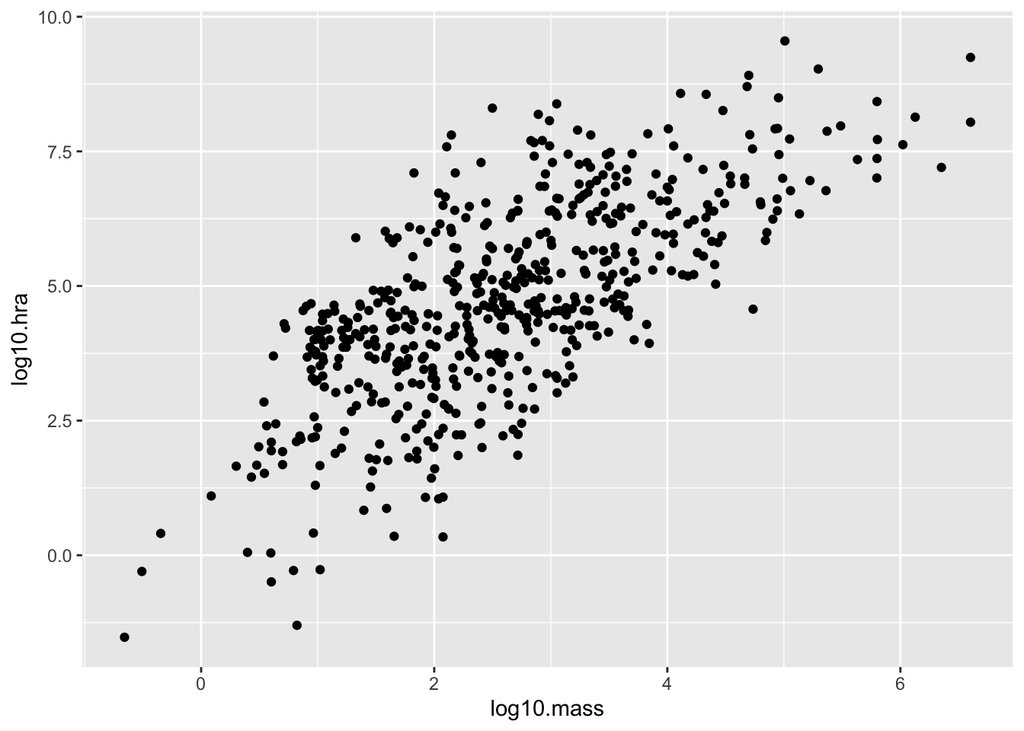

```r
ggplot(hra, aes(x = log10.mass, y = log10.hra)) +
  geom_point()
```

### Question 4

Colorize the points in the scatterplot by `class_fct.`

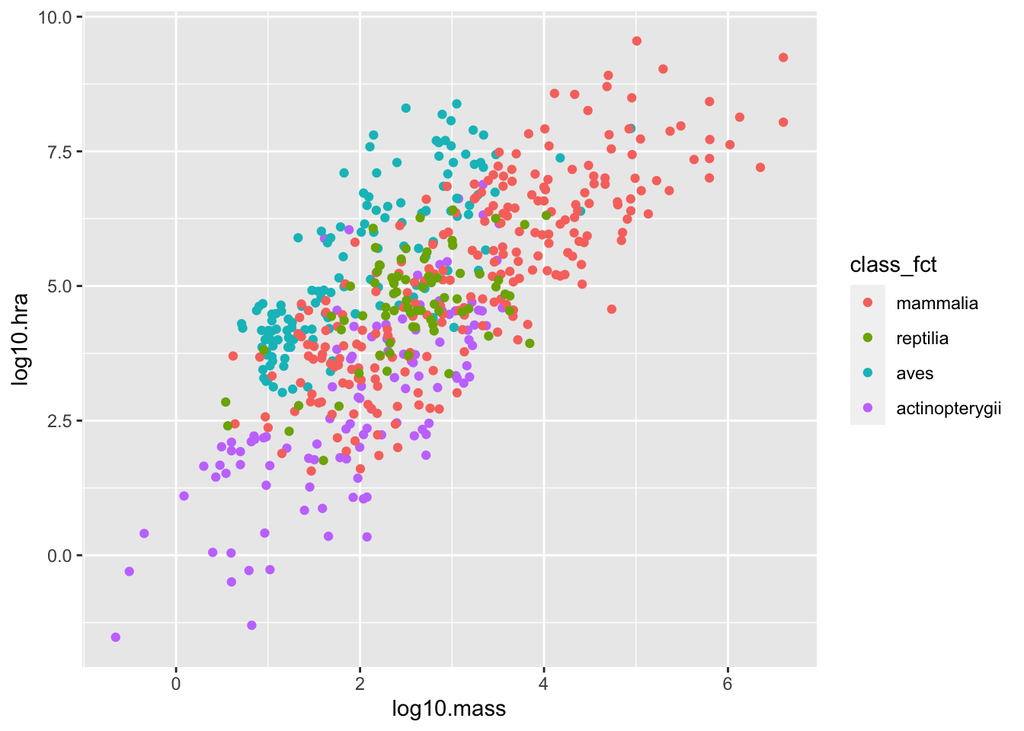

```r
ggplot(hra, aes(x = log10.mass, y = log10.hra)) +
  geom_point(aes(color = class_fct))
```

### Question 5

Display a scatterplot showing only data for birds (`class` aves) and fit a linear regression to that data using the `lm` function.

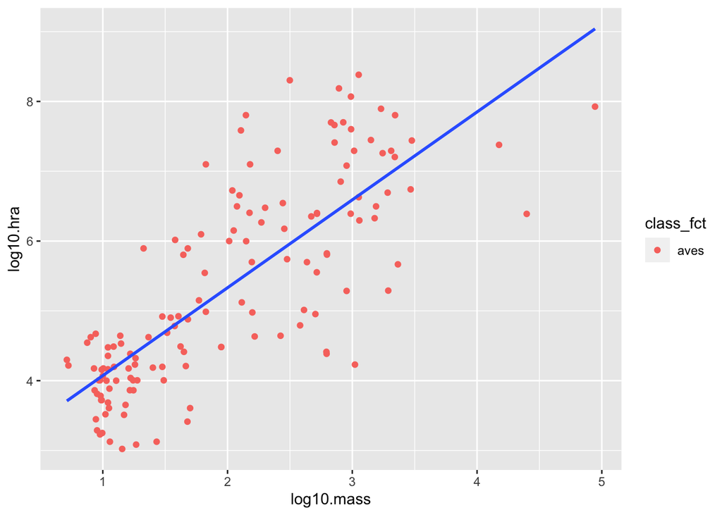

```r
hra %>%
  filter(class == "aves") %>%
  ggplot(aes(x = log10.mass, y = log10.hra)) +
  geom_point(aes(color = class_fct)) +
  geom_smooth(method = "lm", se = FALSE)
```

## Functional programming

[more-sample-exams/#functional-programming](https://education.rstudio.com/blog/2020/08/more-example-exams/#functional-programming)

### Question 1

Write a function called `summarize_table` that takes a title string and a tibble as input and returns a string that says something like, “*title* has *#* rows and *#* columns”. For example, `summarize_table('our table', person)` should return the string `"our table has 5 rows and 3 columns"`.

```r
summarize_table <- function(title, tibble) {
  num_rows <- nrow(tibble)
  num_cols <- ncol(tibble)
  result <- str_c(title,"has", num_rows,
                  "rows and", num_cols, "columns", sep = " ")
  print(result)
}
```

```r
summarize_table("HRA dataset", hra)
```

```
## [1] "HRA dataset has 566 rows and 25 columns"
```

### Question 2

Write another function called `show_columns` that takes a string and a tibble as input and returns a string that says something like, “*table* has columns *name*, *name*, *name*”. For example, `show_columns('person', person)` should return the string `"person has columns person_id, personal_name, family_name"`.

```r
show_columns <- function(title, tibble) {
  col_names <- names(tibble)
  col_names_collapsed <- str_c(col_names, collapse = ", ")
  result <- str_c(title, "has columns",
                  col_names_collapsed, sep = " ")
  print(result)
}
```

```r
show_columns("HRA", hra)
```

```
## [1] "HRA has columns taxon, common.name, class, order, family, genus, species, primarymethod, N, mean.mass.g, log10.mass, alternative.mass.reference, mean.hra.m2, log10.hra, hra.reference, realm, thermoregulation, locomotion, trophic.guild, dimension, preymass, log10.preymass, PPMR, prey.size.ref…
```

### Question 3

The function `rows_from_file` returns the first `N` rows from a table in a CSV file given the file’s name and the number of rows desired. Modify it so that if no value is specified for the number of rows, a default of 3 is used.

```r
# https://www.r-bloggers.com/2015/08/function-argument-lists-and-missing/
# if the argument is optional

rows_from_file <- function(filename, num_rows = NULL){
  name <- readr::read_csv(filename)

    if (is.null(num_rows)){
      head(name, 3)
    } else {
      head(name, n = num_rows)
    }
    #ifelse(num_rows != NA, head(n = num_rows), head(3))
}

# should show 3 rows
rows_from_file("https://education.rstudio.com/blog/2020/08/more-example-exams/measurements.csv")
```

| visit_id | visitor | quantity | reading |
| --- | --- | --- | --- |
| 619 | dyer | rad | 9.82 |
| 619 | dyer | sal | 0.13 |
| 622 | dyer | rad | 7.80 |

### Question 4

The function `long_name` checks whether a string is longer than 4 characters. Use this function and a function from `purrr` to create a logical vector that contains the value `TRUE` where family names in the tibble `person` are longer than 4 characters, and `FALSE` where they are 4 characters or less.

```r
    long_name <- function(name) {
      stringr::str_length(name) > 4
    }

person$family_name %>% map_lgl(long_name)
```

```
## [1] FALSE  TRUE FALSE  TRUE  TRUE
```

## Wrapping up

[more-sample-exams/#wrapping-up](https://education.rstudio.com/blog/2020/08/more-example-exams/#wrapping-up)

Modify the YAML header of this file so that a table of contents is automatically created each time this document is knit, and fix any errors that are preventing the document from knitting cleanly.

```yaml
---
title: "Tidyverse Exam Version 2.0"
output:
html_document:
    theme: flatly
---
```

```yaml
---
title: "Tidyverse Exam Version 2.0"
output:
  html_document: # this was indented
    theme: flatly
    toc: true    # this was added
---
```